# Lab 5 Checkpoint 2

Leticia Wanderley

8/28/2017

### Dados

Para esta análise serão utilizados dados de “speed dating”. Speed dating é uma forma de conhecer pessoas novas rapidamente. Nessa “modalidade” de encontros, várias pessoas se reúnem em um lugar público, como um restaurante, e passam alguns poucos minutos conversando em duplas. Depois que esses minutos se passam as duplas são rearranjadas e o tempo é resetado. Os dados foram obtidos dos participantes desses encontros. Cada participante foi convidado a responder um formulário após cada encontro descrevendo suas impressões sobre a pessoa encontrada. As impressões variam de características físicas, como atratividade (ou nível de atração), para características psicológicas, como sinceridade. Depois do encontro os participantes também atribuiam um veredicto, respondiam se eles queriam ou não encontrar aquela pessoa novamente. É esse veredicto que os modelos de regressão logística tentarão prever.

### 1. Quais fatores têm efeito significativo na chance de p1 decidir se encontrar novamente com p2?

Para responder essa pergunta foram selecionadas 6 variáveis que representam os notas dadas por uma pessoa à pessoa que ela encontrou. Essas variáveis são: interesses em comum, o quão atrante, o quão divertida, o quão inteligente, o quão sincera e o quão ambiciosa a pessoa acha a outra.

```r
bm.1 <- glm(dec ~ shar + attr + fun + intel + sinc + amb,
          data = dates,
          family = "binomial")
tidy(bm.1, conf.int = TRUE, exponentiate = FALSE)
```

```
##          term    estimate  std.error   statistic      p.value    conf.low
## 1 (Intercept) -5.46322503 0.38914329 -14.0391089 8.983514e-45 -6.24242873
## 2        shar  0.28974476 0.03653420   7.9307805 2.177728e-15  0.21881779
## 3        attr  0.55985635 0.04564753  12.2647687 1.400114e-34  0.47177823
## 4         fun  0.21536423 0.04949916   4.3508661 1.356008e-05  0.11892046
## 5       intel  0.04251405 0.06159827   0.6901825 4.900794e-01 -0.07855172
## 6        sinc -0.05524142 0.04979099  -1.1094660 2.672292e-01 -0.15303393
## 7         amb -0.18516985 0.04834952  -3.8298174 1.282384e-04 -0.28082045
##     conf.high
## 1 -4.71628698
## 2  0.36213628
## 3  0.65082979
## 4  0.31310130
## 5  0.16306081
## 6  0.04227782
## 7 -0.09116491
```

Observando cuidadosamente os valores de confiança estimados para cada valor se percebe que os intervalos de confiança do quão inteligente e o quão sincera a pessoa pareceu ser incluem o valor 0. Ambos os intervalos incluem números negativos e positivos, isto é um indicativo de que esses valores não são significativos, não se pode afirmar se eles contribuem positiva ou negativamente no match.

```r
tidy(bm.1, conf.int = TRUE, exponentiate = TRUE)
```

```
##          term   estimate  std.error   statistic      p.value    conf.low
## 1 (Intercept) 0.00423986 0.38914329 -14.0391089 8.983514e-45 0.001945126
## 2        shar 1.33608642 0.03653420   7.9307805 2.177728e-15 1.244604475
## 3        attr 1.75042103 0.04564753  12.2647687 1.400114e-34 1.602841888
## 4         fun 1.24031358 0.04949916   4.3508661 1.356008e-05 1.126280333
## 5       intel 1.04343071 0.06159827   0.6901825 4.900794e-01 0.924454244
## 6        sinc 0.94625668 0.04979099  -1.1094660 2.672292e-01 0.858100606
## 7         amb 0.83096314 0.04834952  -3.8298174 1.282384e-04 0.755163916
##     conf.high
## 1 0.008948342
## 2 1.436394684
## 3 1.917130979
## 4 1.367660068
## 5 1.177108272
## 6 1.043184254
## 7 0.912867157
```

Ao observar os valores das estimativas exponeciados se tem o mesmo resultado. As variáveis o quão inteligente e o quão sincera a pessoa pareceu ser estão dentro de intervalos que incluem tanto valores maiores quanto menores que 1, um indicativo da não significância dessas estimativas. A partir das estimativas exponenciadas se pode ainda qualificar o efeito que uma variável tem no match. As variáveis interesses em comum, o quão atrante, o quão divertida uma pessoa acha a outra, têm efeito positivo no resultado do match. Já o quão ambiciosa uma pessoa acha a outra tem efeito negativo.

```r
pR2(bm.1)
```

```
##           llh       llhNull            G2      McFadden          r2ML
##  -836.4884288 -1109.3187884   545.6607192     0.2459441     0.2856715
##          r2CU
##     0.3832748
```

Uma forma de analisar o quanto um modelo explica os dados, na regressão logística, é utilizando o pseudo R² de McFadden. Nesse caso essa métrica indica que aproximadamente 24.6% dos matchs conseguem ser explicados pelo modelo criado.

> Efeito positivo: interesses em comum, o quão atraente, o quão divertida. Efeito negativo: o quão ambiciosa.

### 2. Que fatores nos dados têm mais efeito na chance de um participante querer se encontrar novamente com outro?

Excluindo as duas variáveis que não apresentam significância, o quão inteligente e o quão sincera a pessoa pareceu ser, se tem um modelo de 4 variáveis, interesses em comum, o quão atrante, o quão divertida e o quão ambiciosa uma pessoa acha a outra.

```r
bm.2<- glm(dec ~ shar + attr + fun + amb,
          data = dates,
          family = "binomial")
tidy(bm.2, conf.int = TRUE, exponentiate = TRUE)
```

```
##          term   estimate  std.error  statistic      p.value    conf.low
## 1 (Intercept) 0.00416785 0.35038616 -15.640900 3.832705e-55 0.002063994
## 2        shar 1.33193066 0.03637112   7.880690 3.255792e-15 1.241146493
## 3        attr 1.74076396 0.04510661  12.289198 1.035277e-34 1.595753214
## 4         fun 1.22666759 0.04712075   4.335695 1.453002e-05 1.119137302
## 5         amb 0.83815446 0.04290445  -4.115025 3.871374e-05 0.769847040
##     conf.high
## 1 0.008156563
## 2 1.431489415
## 3 1.904605274
## 4 1.346354227
## 5 0.910955869
```

A variável com mais influência sobre a probabilidade de match é o quão atraente a pessoa parece ser, seguida pelos proporção de interesses em comum e pelo quão divertida e o quão ambiciosa a outra pessoa parece ser. Apesar da variável que representa a ambição ter efeito negativo sua influência absoluta se equipara à do quão divertida a pessoa parece ser.

```r
pR2(bm.2)
```

```
##           llh       llhNull            G2      McFadden          r2ML
##  -837.1315390 -1109.3187884   544.3744989     0.2453643     0.2851048
##          r2CU
##     0.3825145
```

De acordo com o pseudo R² de McFadden este modelo explica cerca de 24.5% dos dados.

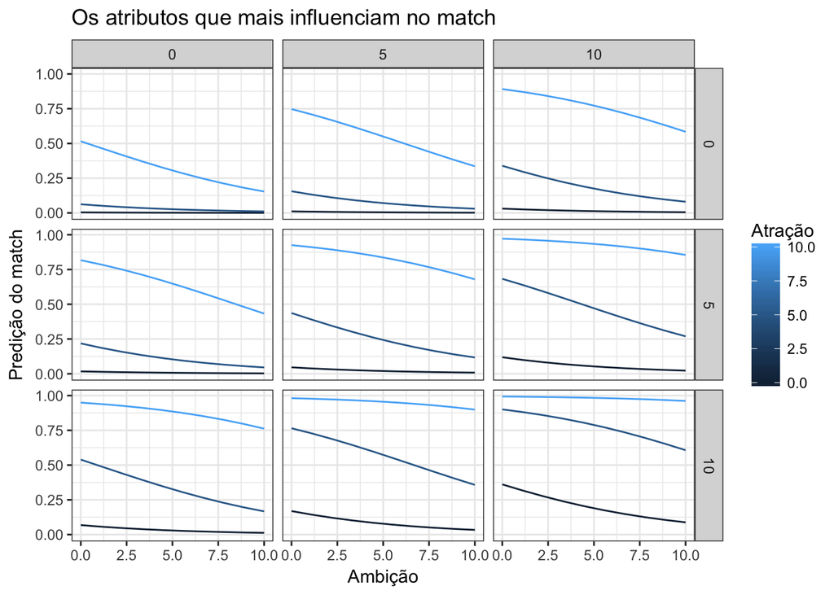

```r
model.2 = dates %>%
  data_grid(shar = seq_range(shar, 3),
            attr = seq_range(attr, 3),
            fun = seq_range(fun, 3),
            amb = seq_range(amb, 10))
mm = augment(bm.2,
             newdata = model.2,
             type.predict = "response")
mm %>%
  ggplot(aes(x = amb, colour=attr)) +
  geom_line(aes(y = .fitted, group=attr)) +
  facet_grid(shar ~ fun) +
  labs(title="Os atributos que mais influenciam no match", x="Ambição", y="Predição do match", colour="Atração")
```

Como já previsto o quão ambiciosa a pessoa pareceu ser tem efeito negativo no resultado do match, por esse motivo a linhas do gráfico tem inclinação descendente (negativa). Também é possível notar o quanto a atração influencia positivamente no resultado, estando a linha mais clara sempre muito acima das outras linhas. Também se vê que, quando comparadas, a variável dos interesses em comum tem mais influência que a variável do quão divertida a pessoa pareceu ser. Observando o gráfico de baixo da coluna mais a esquerda e o gráfico de cima da coluna mais à direita se vê que o primeiro, quando os interesses em comum têm valor alto e o quão divertida tem valor baixo, apresenta predições mais altas que o último, quando os interesses em comum têm valor baixo e o quão divertida tem valor alto.